# Individual project

## This dataset is called “Infogears”. Since, nowadays the world is fighting against coronavirus, I have decided to take it and get new, more interesting staff and compare them with information we get every day. The data is a new one; more and more rows are added daily. And, since the data is new, there is no much statistics done on it.

## Hypothesis: Let’s understand does the society wear masks, does wearing masks useful and what are the common symptoms of the virus.

Here is my github link: https://github.com/Anahit-Manukyan/Infogears/tree/master

## Let’s look at the structure of the dataset.

```
## [1] "Number of observations: 30088"
```

```
## [1] "Number of variables: 33"
```

As we can see, there exist 30088 observations and 33 variables in our data set.  
Among which householdHeadcount is numerical, and the symptoms are in an integer type since, as we can see, each person checked he/she has the symptom (1) or not (0).

## First of all, let’s clean the data and make it more practical.

The values in the original dataset

```
## [1] "interval_36_45"       "interval_26_35"       "interval_46_55"
## [4] "interval_18_25"       "interval_66_75"       "interval_13_17"
## [7] "interval_75_and_more" "interval_56_65"
```

Here are the new values of the variable “age”

```
## [1] "36-45" "26-36" "46-55" "18-25" "66-75" "13-17" "75+"   "56-65"
```

3. Let’s understand which columns we need.

```
##  [1] "age"                 "antibodyTest"        "createdAt"
##  [4] "exposureLevel"       "faceCovering"        "gender"
##  [7] "healthIssues"        "householdHeadcount"  "leftHomeTimes"
## [10] "mentalHealthImpact"  "updatedAt"           "virusTest"
## [13] "zipCode"             "bodyAche"            "diarrhea"
## [16] "difficultyBreathing" "disorientation"      "fatigue"
## [19] "headAche"            "id"                  "irritatedEyes"
## [22] "leftForExercise"     "leftForOther"        "leftForShopping"
## [25] "leftForWork"         "lossOfSmell"         "noSymptoms"
## [28] "persistentCough"     "soreThroat"          "temperature"
```

Since, in my opinion, we do not need the information about user agent, I have deleted the column.  
As a result, we are left with 30 columns.

3. Let’s make numerical variables factors, in order to do the calculations easily.

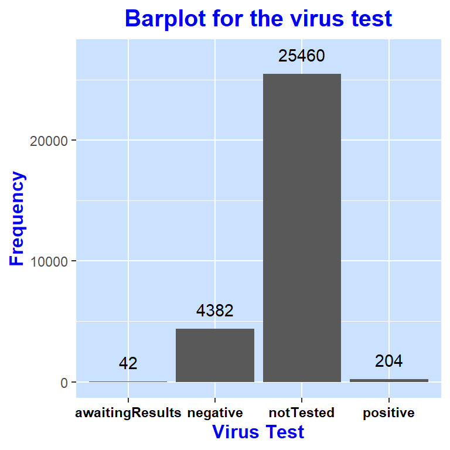

As we can see most of the patients are not tested or negatively tested, as a result, we cannot get  
clear results regarding the infected people.

## Lets understand the test results and household headcount.

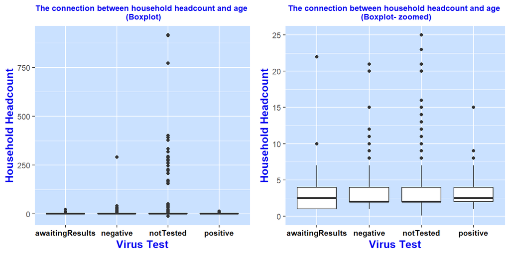

## Let’s have a closer look on the virus test results.

```
## [1] "Positive: 204"
```

```
## [1] "Awaiting results: 42"
```

```
## [1] "Negative: 4382"
```

As we can see, majority of the people in this dataset are not tested.  
However, from 30088 observations only 204 have the virus.

## Let’s understand, does the society wear masks or not, and how it influences the spreading of the virus.

```
## [1] "Never wore a mask: 693"
```

```
## [1] "Always wore a mask: 16625"
```

```
## [1] "Sometime wore a mask: 4439"
```

As we can see, the majority of people wore masks.  
Let’s understand how much wearing masks is dependent to the test being positive.

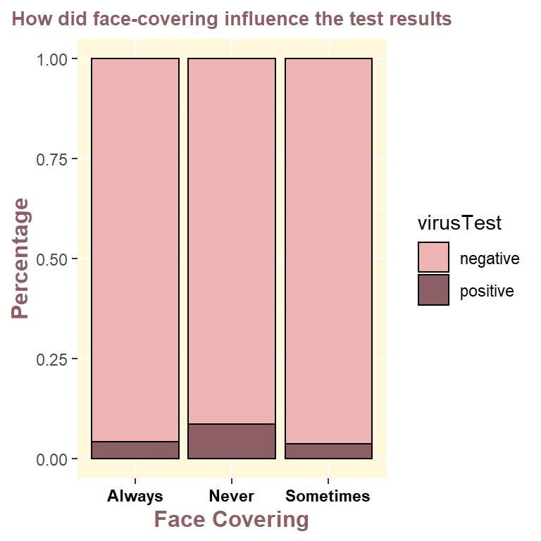

As we can see, the people who never wore a mask had more changes of getting the virus,than the people who always or sometimes wore the masks. However, the results of wearing sometimes or always nearly do not vary.

## Here are the major symptoms of the people with positive test results

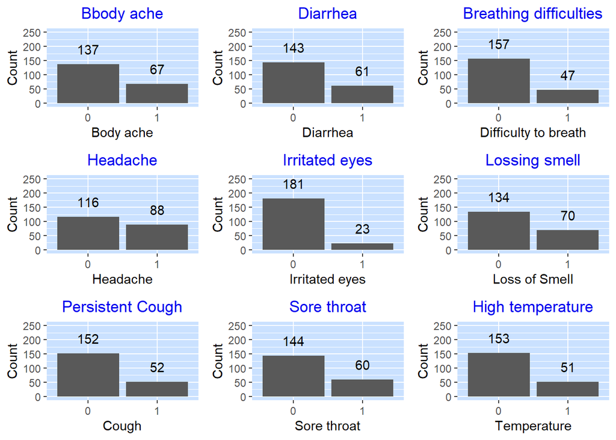

## Since headache is the most common symptom, let’s understand does it vary from gender to gender

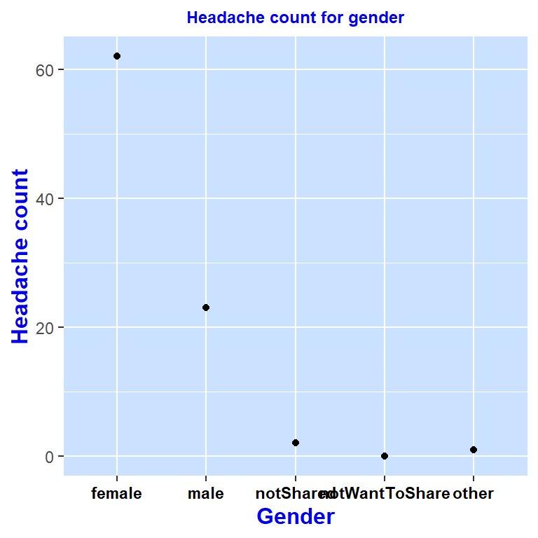

Here are the people who have the virus and experience headache. As we can see, women are more likely to have headaches.

## As the thesis statement suggests, we are going to find the people with the virus who shared information about their communication.

We are going to take a close look at a random zip code and find out the problems at that neighborhood

```
## [1] "As a result, there exists 5903 zip codes in our dataframe, among which in 167 unique zip codes people with the vius live/work"
```

By checking the length of unique values of Zip Code, I wanted to understand if there exist people from the same neighborhood of from the same family. Since, from 30088 observations only 5903 are unique, we can understand that there exist many people having some contact to each other.

```
## [1] "52 people, who have the virus had direct contact with others."
```

Let’s understand, did they wore the masks or not.

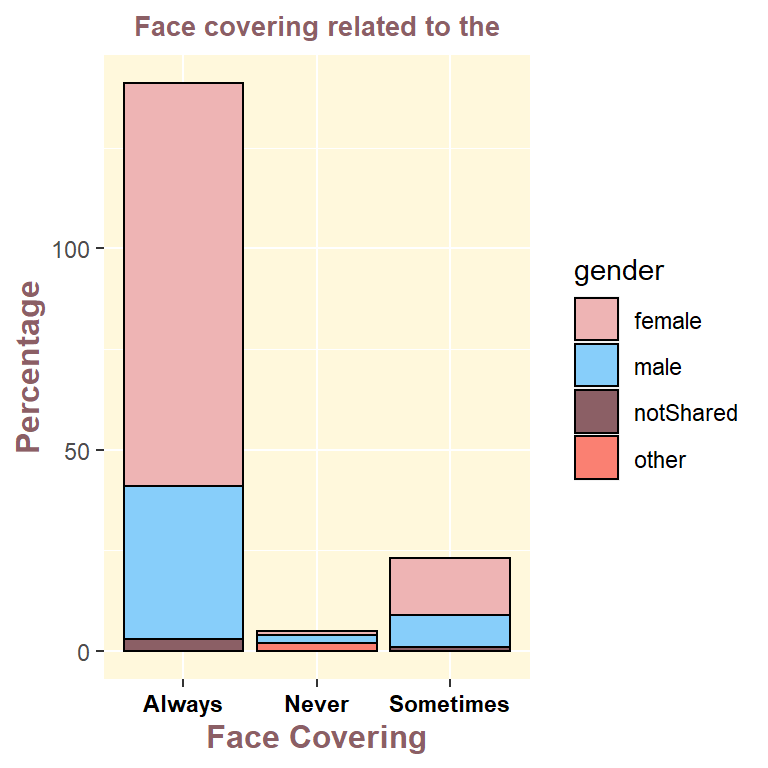

## Lets try to find a neighborhood, where the virus is more spread.

```
## # A tibble: 1 x 2
##   zipCode  Freq
##   <chr>   <int>
## 1 10111       3
```

[output not shown]

[output not shown]

[output not shown]

[output not shown]

[output not shown]

[output not shown]

Creating a frequency table is a simple but effective way of finding distribution between the two categorical variables. The table() function can be used to create the two way table between two variables.

```
##
##                     Always Never Sometimes
##   noImpact            1965   183       611
##   significantImpact   4746   117       879
##   someImpact          9914   393      2949
```

Cell percentages

```
##
##                          Always       Never   Sometimes
##   noImpact          0.090315760 0.008411086 0.028082916
##   significantImpact 0.218136692 0.005377580 0.040400791
##   someImpact        0.455669440 0.018063152 0.135542584
```

Row percentages

```
##
##                         Always      Never  Sometimes
##   noImpact          0.71221457 0.06632838 0.22145705
##   significantImpact 0.82654127 0.02037618 0.15308255
##   someImpact        0.74788775 0.02964695 0.22246530
```

Column percentages

```
##
##                        Always     Never Sometimes
##   noImpact          0.1181955 0.2640693 0.1376436
##   significantImpact 0.2854737 0.1688312 0.1980176
##   someImpact        0.5963308 0.5670996 0.6643388
```

## As we see masks are actually useful. The only thing that I would suggest is that people, especially the ones who are tested positively, sould wear masks to protect lives.